# R Notebook

```r
library(janitor)
```

[output not shown]

[output cut: 990 more lines]

## Part 1

### Question 1

Take the data in the dataset qb_revenue_breakdown and make a stacked bar chart showing the sources of revenue across the two years in the dataset.

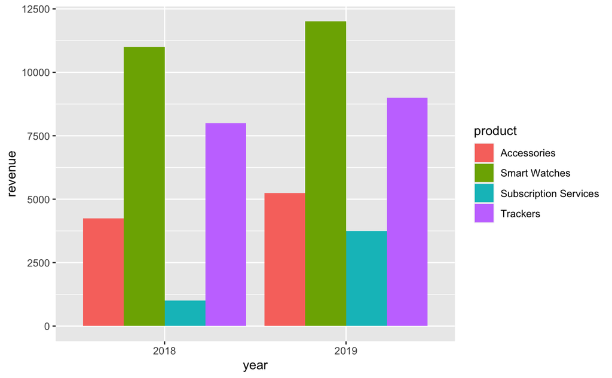

### Question 2

Make a line chart showing monthly sales of the “flagship product” - the ‘KwikBit Unit 1’ - over the last year. This data is inside qb_monthly_sales, but you will need to use filter() or subset() (base R).

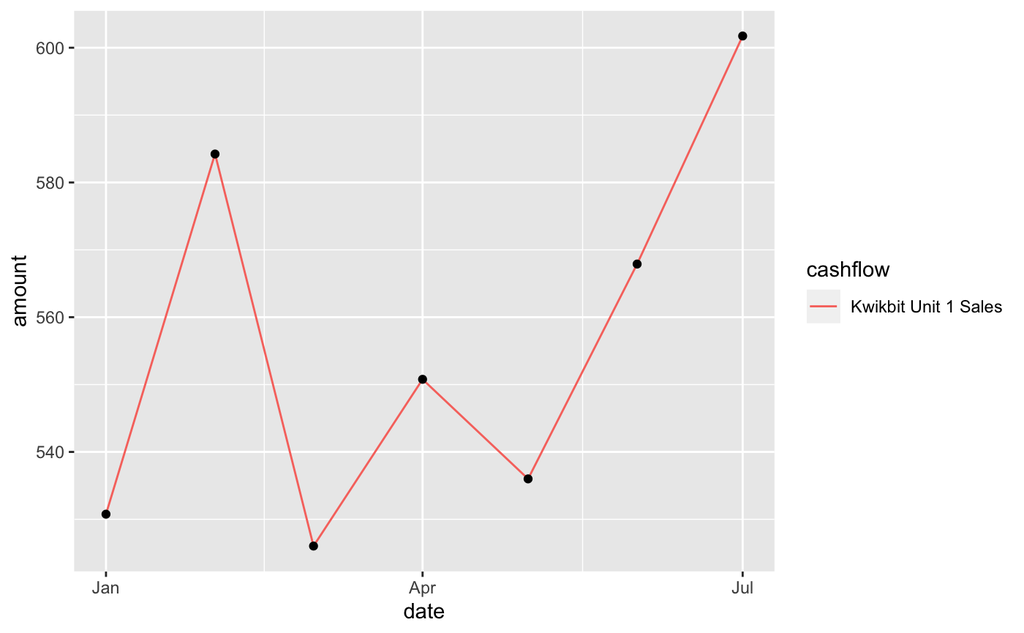

### Question 3

Make a line chart showing monthly revenue and costs over the last year. This data is also in qb_monthly_sales.

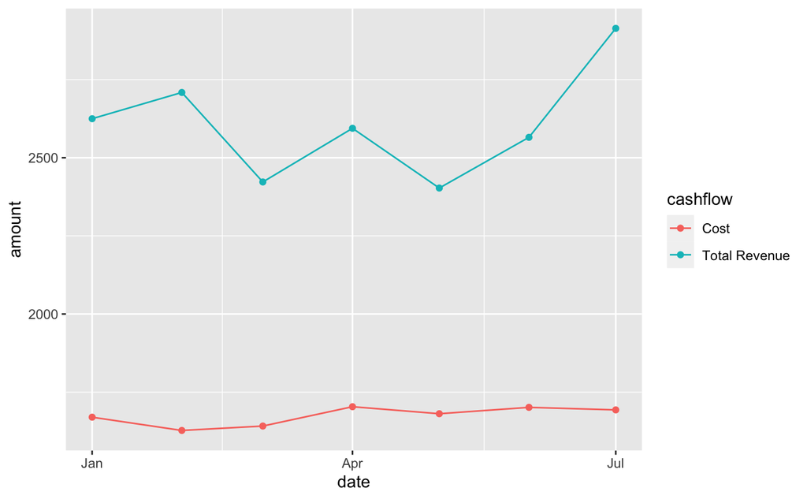

### Question 4

Show annual sales of personal fitness trackers over the last 5 years broken down by company as a ribbon plot (use geom_area). This data is in qb_competitors.

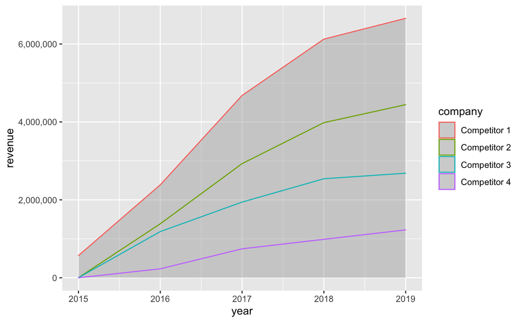

### Question 5

Now show the sales from the four competitors as a line graph. Include an extra layer that shows the data points used to make the lines.

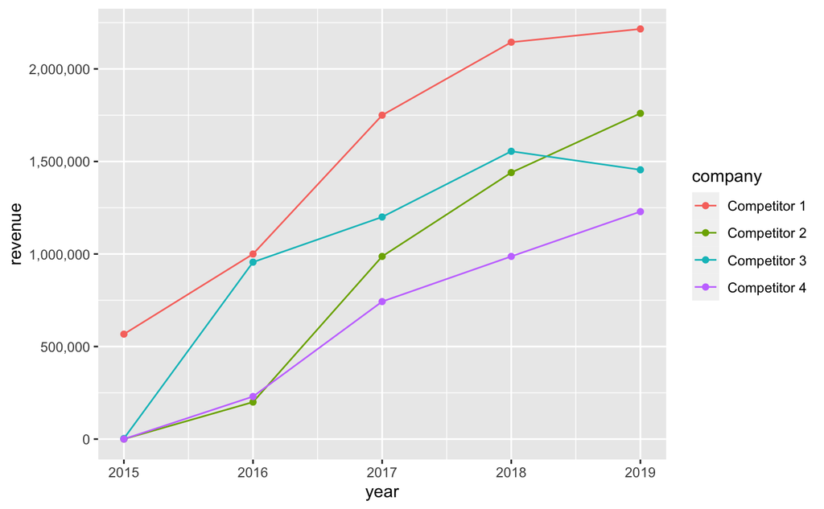

### Question 6

Now the company wants to compare the number of steps that their device counts vs. their competitors. Make a line graph of the number of steps throughout time, and use faceting to compare between companies and people. The data for this is in qb_device_data.

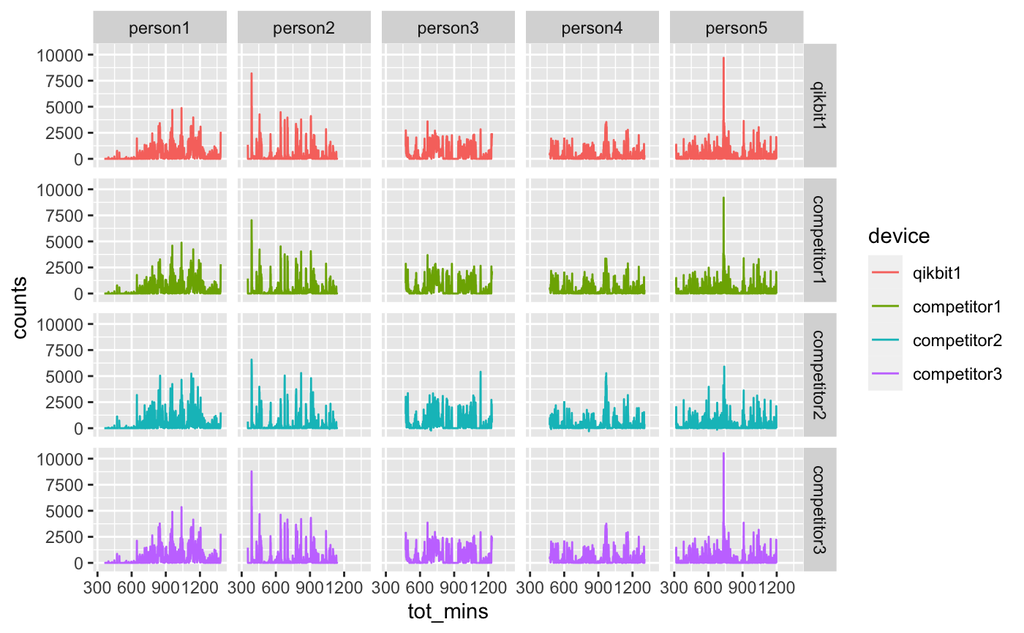